# Lab 5a: Sampling Distributions

Jeff Parks

2021-10-10

```r
library(tidyverse)
library(openintro)
library(infer)

set.seed(1234)

global_monitor <- tibble(
  scientist_work = c(rep("Benefits", 80000), rep("Doesn't benefit", 20000))
)
```

### Exercise 1

**Describe the distribution of responses in this sample. How does it compare to the distribution of responses in the population?**

The distribution of responses in this sample (74% benefits / 26% not) is very similar to the population distribution (80% benefits / 20% not.)

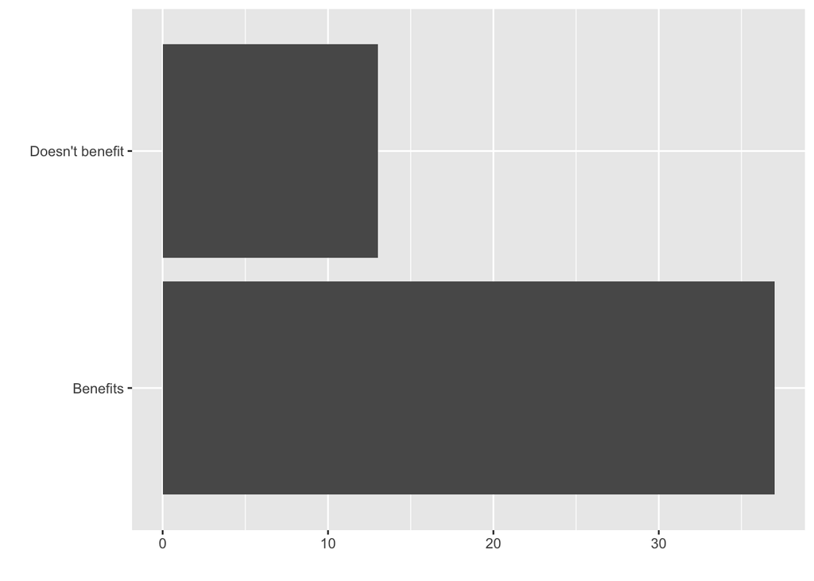

```r
samp1 <- global_monitor %>%
  sample_n(50)

ggplot(samp1, aes(x=scientist_work)) +
  geom_bar() +
  coord_flip() +
  labs(x="",y="")
```

```r
samp1 %>%
  count(scientist_work) %>%
  mutate(p_hat=n/sum(n))
```

```
## # A tibble: 2 × 3
##   scientist_work      n p_hat
##   <chr>           <int> <dbl>
## 1 Benefits           37  0.74
## 2 Doesn't benefit    13  0.26
```

### Exercise 2

**Would you expect the sample proportion to match the sample proportion of another student’s sample? Why, or why not? If the answer is no, would you expect the proportions to be somewhat different or very different?**

I would not expect my sample proportion to exactly match another student’s sample, as there is random variability between samples. However, I would expect the two sample proportions to be somewhat similar, and similar to the population proportion.

### Exercise 3

**Take a second sample, also of size 50, and call it samp2. How does the sample proportion of samp2 compare with that of samp1? Suppose we took two more samples, one of size 100 and one of size 1000. Which would you think would provide a more accurate estimate of the population proportion?**

Sample 2 in this case was slightly closer to the population proportion than Sample 1, although they used the same sample size.

Samples 3 and 4 displayed greater similarity to the population proportion as the sample sizes increased. I would expect Sample 4 (n=1000) to provide a more accurate estimate of the population proportion.

```r
samp2 <- global_monitor %>% sample_n(50)

samp2 %>%
  count(scientist_work) %>%
  mutate(p_hat=n/sum(n))
```

```
## # A tibble: 2 × 3
##   scientist_work      n p_hat
##   <chr>           <int> <dbl>
## 1 Benefits           42  0.84
## 2 Doesn't benefit     8  0.16
```

```r
samp3 <- global_monitor %>% sample_n(100)

samp3 %>%
  count(scientist_work) %>%
  mutate(p_hat=n/sum(n))
```

```
## # A tibble: 2 × 3
##   scientist_work      n p_hat
##   <chr>           <int> <dbl>
## 1 Benefits           81  0.81
## 2 Doesn't benefit    19  0.19
```

```r
samp4 <- global_monitor %>% sample_n(1000)

samp4 %>%
  count(scientist_work) %>%
  mutate(p_hat=n/sum(n))
```

```
## # A tibble: 2 × 3
##   scientist_work      n p_hat
##   <chr>           <int> <dbl>
## 1 Benefits          798 0.798
## 2 Doesn't benefit   202 0.202
```

### Exercise 4

**How many elements are there in sample_props50? Describe the sampling distribution, and be sure to specifically note its center. Make sure to include a plot of the distribution in your answer.**

There are 15,000 elements in sample_props50, representing the “Doesn’t benefit” proportion for each of the 15,000 population samples. The mean of this sampling distribution is 0.1991827, very close to the population mean of 0.2.

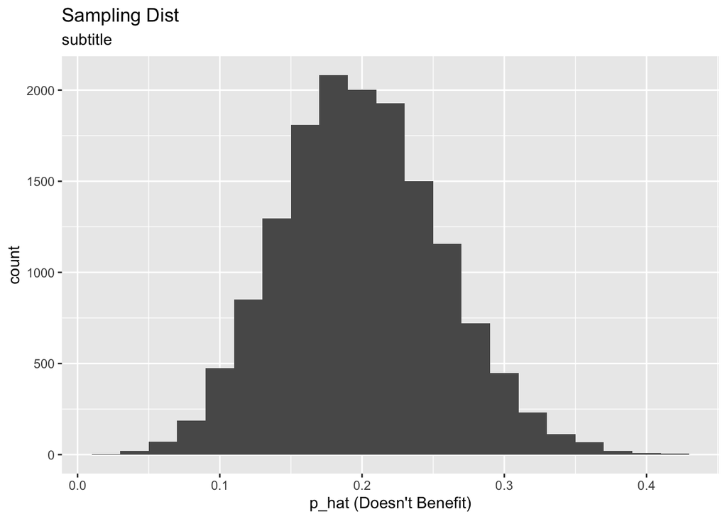

```r
sample_props50 <- global_monitor %>%
  rep_sample_n(size=50, reps=15000, replace=TRUE) %>%
  count(scientist_work) %>%
  mutate(p_hat = n/sum(n)) %>%
  filter(scientist_work == "Doesn't benefit")

ggplot(sample_props50, aes(x=p_hat)) +
  geom_histogram(binwidth=0.02) +
  labs(
    x="p_hat (Doesn't Benefit)",
    title="Sampling Dist",
    subtitle="subtitle"
  )
```

```r
mean(sample_props50$p_hat)
```

```
## [1] 0.1991827
```

### Exercise 5

**Try modifying the code to create a sampling distribution of 25 sample proportions from samples of size 10, and put them in a data frame named sample_props_small. Print the output. How many observations are there in this object called sample_props_small? What does each observation represent?**

There are 250 total observations in sample_props_small - each represents one of two possible results (“Benefits” or “Doesn’t Benefit”) over 25 repetitions of a sample from the population, each with sample size 10. The “replicate” column contains an index of the repetition group a particular observation belongs to.

```r
sample_props_small <- global_monitor %>%
  rep_sample_n(size=10, reps=25, replace=TRUE)

summary(sample_props_small)
```

```
##    replicate  scientist_work
##  Min.   : 1   Length:250
##  1st Qu.: 7   Class :character
##  Median :13   Mode  :character
##  Mean   :13
##  3rd Qu.:19
##  Max.   :25
```

```r
head(sample_props_small,10)
```

```
## # A tibble: 10 × 2
## # Groups:   replicate [1]
##    replicate scientist_work
##        <int> <chr>
##  1         1 Benefits
##  2         1 Doesn't benefit
##  3         1 Benefits
##  4         1 Benefits
##  5         1 Benefits
##  6         1 Benefits
##  7         1 Benefits
##  8         1 Benefits
##  9         1 Benefits
## 10         1 Doesn't benefit
```

### Exercise 6

**Create sampling distributions of proportions of “Doesn’t Benefit” from samples of size 10, 50 and 100. Use 5,000 simulations. What does each observation in the sampling distribution represent? How does the mean, standard error, and shape of the sampling distribution change as the sample size increases? How (If at all) do those values change is you increase the number of simulations?**